# practice_text

やわらかクジラ

2023/07/11

# 1 参考

## 1.1 全般

- [Text Mining with R: A Tidy Approach (Julia Silge and David Robinson)](https://www.tidytextmining.com/index.html)

## 1.2 quanteda

- [クイック・スタートガイド](https://quanteda.io/articles/pkgdown/quickstart_ja.html)
- [quanteda tutorials](https://tutorials.quanteda.io/multilingual/japanese/)
- [経済学における量的テキスト分析入門](https://github.com/koheiw/workshop-JEAT)
- [Rによる日本語のテキスト分析入門](https://github.com/koheiw/workshop-IJTA)
- [フリーソフトによるデータ解析・マイニング](https://www.cis.doshisha.ac.jp/mjin/R/index.html)

## 1.3 用語

- 形態素 morpheme
- 形態素解析 morphological analysis
- 分かち書き word segmentation
- レンマ化，見出し語化 lemmatization

# 2 準備

## 2.1 パッケージ読み込み

```r
library(tidyverse)
library(quanteda)
```

# 3 大きな文章を読み込んで分割

## 3.1 読み込み

- 太宰治[『女生徒』](https://www.aozora.gr.jp/cards/000035/card275.html)青空文庫
- ここではダウンロードして回答したフォルダ`275_ruby_1532`をdataフォルダの中に置く

```r
# 1行ごと読み込む関数だが，青空文庫の仕様上，段落（１行？）ごとに読み込み？
dat_txt <-
  readr::read_lines("data/275_ruby_1532/joseito.txt",
                    locale = locale(encoding = "cp932"))

dat_txt |>
  head(20)
```

```
##  [1] "女生徒"
##  [2] "太宰治"
##  [3] ""
##  [4] "-------------------------------------------------------"
##  [5] "【テキスト中に現れる記号について】"
##  [6] ""
##  [7] "《》：ルビ"
##  [8] "（例）襖《ふすま》"
##  [9] ""
## [10] "｜：ルビの付く文字列の始まりを特定する記号"
## [11] "（例）夕｜靄《もや》は"
## [12] ""
## [13] "［＃］：入力者注　主に外字の説明や、傍点の位置の指定"
## [14] "　　　（数字は、JIS X 0213の面区点番号またはUnicode、底本のページと行数）"
## [15] "（例）※［＃「さんずい＋（壥－土へん－厂）」、第3水準1-87-25］"
## [16] "-------------------------------------------------------"
## [17] ""
## [18] "　あさ、眼をさますときの気持は、面白い。かくれんぼのとき、押入れの真っ暗い中に、じっと、しゃがんで隠れていて、突然、でこちゃんに、がらっと襖《ふすま》をあけられ、日の光がどっと来て、でこちゃんに、「見つけた！」と大声で言われて、まぶしさ、それから、へんな間の悪さ、それから、胸がどきどきして、着物のまえを合せたりして、ちょっと、てれくさく、押入れから出て来て、急にむかむか腹立たしく、あの感じ、いや、ちがう、あの感じでもない、なんだか、もっとやりきれない。箱をあけると、その中に、また小さい箱があって、その小さい箱をあけると、またその中に、もっと小さい箱があって、そいつをあけると、…
## [19] "　朝は、意地悪《いじわる》。"
## [20] "「お父さん」と小さい声で呼んでみる。へんに気恥ずかしく、うれしく、起きて、さっさと蒲団《ふとん》をたたむ。蒲団を持ち上げるとき、よいしょ、と掛声して、はっと思った。私は、いままで、自分が、よいしょなんて、げびた言葉を言い出す女だとは、思ってなかった。よいしょ、なんて、お婆さんの掛声みたいで、いやらしい。どうして、こんな掛声を発したのだろう。私のからだの中に、どこかに、婆さんがひとつ居るようで、気持がわるい。これからは、気をつけよう。ひとの下品な歩き恰好《かっこう》を顰蹙《ひんしゅく》していながら、ふと、自分も、そんな歩きかたしているのに気がついた時みたいに、すごく、しょげちゃ…
```

```r
# 文章開始までの部分を削除
dat_txt <-
  dat_txt[-(1:17)]

dat_txt |>
  tail(20)
```

```
##  [1] "「いいの、そんなに欲しくなくなったの」"
##  [2] "「でも、なければ、困るでしょう」"
##  [3] "「うん」"
##  [4] "　明日もまた、同じ日が来るのだろう。幸福は一生、来ないのだ。それは、わかっている。けれども、きっと来る、あすは来る、と信じて寝るのがいいのでしょう。わざと、どさんと大きい音たてて蒲団にたおれる。ああ、いい気持だ。蒲団が冷いので、背中がほどよくひんやりして、ついうっとりなる。幸福は一夜おくれて来る。ぼんやり、そんな言葉を思い出す。幸福を待って待って、とうとう堪え切れずに家を飛び出してしまって、そのあくる日に、素晴らしい幸福の知らせが、捨てた家を訪れたが、もうおそかった。幸福は一夜おくれて来る。幸福は、――"
##  [5] "　お庭をカアの歩く足音がする。パタパタパタパタ、カアの足音には、特徴がある。右の前足が少し短く、それに前足はＯ型でガニだから、足音にも寂しい癖があるのだ。よくこんな真夜中に、お庭を歩きまわっているけれど、何をしているのかしら。カアは、可哀想。けさは、意地悪してやったけれど、あすは、かわいがってあげます。"
##  [6] "　私は悲しい癖で、顔を両手でぴったり覆っていなければ、眠れない。顔を覆って、じっとしている。"
##  [7] "　眠りに落ちるときの気持って、へんなものだ。鮒《ふな》か、うなぎか、ぐいぐい釣糸をひっぱるように、なんだか重い、鉛みたいな力が、糸でもって私の頭を、ぐっとひいて、私がとろとろ眠りかけると、また、ちょっと糸をゆるめる。すると、私は、はっと気を取り直す。また、ぐっと引く。とろとろ眠る。また、ちょっと糸を放す。そんなことを三度か、四度くりかえして、それから、はじめて、ぐうっと大きく引いて、こんどは朝まで。"
##  [8] "　おやすみなさい。私は、王子さまのいないシンデレラ姫。あたし、東京の、どこにいるか、ごぞんじですか？　もう、ふたたびお目にかかりません。"
##  [9] ""
## [10] ""
## [11] ""
## [12] "底本：「女生徒」角川文庫、角川書店"
## [13] "　　　1954（昭和29）年10月20日初版発行"
## [14] "　　　1968（昭和43）年2月5日44版発行"
## [15] "入力：細渕真弓"
## [16] "校正：細渕紀子"
## [17] "1999年2月16日公開"
## [18] "2011年5月22日修正"
## [19] "青空文庫作成ファイル："
## [20] "このファイルは、インターネットの図書館、青空文庫（http://www.aozora.gr.jp/）で作られました。入力、校正、制作にあたったのは、ボランティアの皆さんです。"
```

```r
# 文章最終文の後の部分を削除
dat_txt <-
  dat_txt[-(96:107)]

dat_txt |>
  tail()
```

```
## [1] "「うん」"
## [2] "　明日もまた、同じ日が来るのだろう。幸福は一生、来ないのだ。それは、わかっている。けれども、きっと来る、あすは来る、と信じて寝るのがいいのでしょう。わざと、どさんと大きい音たてて蒲団にたおれる。ああ、いい気持だ。蒲団が冷いので、背中がほどよくひんやりして、ついうっとりなる。幸福は一夜おくれて来る。ぼんやり、そんな言葉を思い出す。幸福を待って待って、とうとう堪え切れずに家を飛び出してしまって、そのあくる日に、素晴らしい幸福の知らせが、捨てた家を訪れたが、もうおそかった。幸福は一夜おくれて来る。幸福は、――"
## [3] "　お庭をカアの歩く足音がする。パタパタパタパタ、カアの足音には、特徴がある。右の前足が少し短く、それに前足はＯ型でガニだから、足音にも寂しい癖があるのだ。よくこんな真夜中に、お庭を歩きまわっているけれど、何をしているのかしら。カアは、可哀想。けさは、意地悪してやったけれど、あすは、かわいがってあげます。"
## [4] "　私は悲しい癖で、顔を両手でぴったり覆っていなければ、眠れない。顔を覆って、じっとしている。"
## [5] "　眠りに落ちるときの気持って、へんなものだ。鮒《ふな》か、うなぎか、ぐいぐい釣糸をひっぱるように、なんだか重い、鉛みたいな力が、糸でもって私の頭を、ぐっとひいて、私がとろとろ眠りかけると、また、ちょっと糸をゆるめる。すると、私は、はっと気を取り直す。また、ぐっと引く。とろとろ眠る。また、ちょっと糸を放す。そんなことを三度か、四度くりかえして、それから、はじめて、ぐうっと大きく引いて、こんどは朝まで。"
## [6] "　おやすみなさい。私は、王子さまのいないシンデレラ姫。あたし、東京の、どこにいるか、ごぞんじですか？　もう、ふたたびお目にかかりません。"
```

```r
 # dat_txt <- readtext::readtext("data/275_ruby_1532/joseito.txt", cache = FALSE)
```

### 3.1.1 ルビを取り除く

- https://mjin.doshisha.ac.jp/R/57/57.html
  - “[^》]+”は、記号”》“以外のすべての文字列

```r
# 除去前
dat_txt[1]
```

```
## [1] "　あさ、眼をさますときの気持は、面白い。かくれんぼのとき、押入れの真っ暗い中に、じっと、しゃがんで隠れていて、突然、でこちゃんに、がらっと襖《ふすま》をあけられ、日の光がどっと来て、でこちゃんに、「見つけた！」と大声で言われて、まぶしさ、それから、へんな間の悪さ、それから、胸がどきどきして、着物のまえを合せたりして、ちょっと、てれくさく、押入れから出て来て、急にむかむか腹立たしく、あの感じ、いや、ちがう、あの感じでもない、なんだか、もっとやりきれない。箱をあけると、その中に、また小さい箱があって、その小さい箱をあけると、またその中に、もっと小さい箱があって、そいつをあけると、ま…
```

```r
dat_txt <-
  dat_txt |>
  str_remove_all("《[^》]+》")

# 除去後
dat_txt[1]
```

```
## [1] "　あさ、眼をさますときの気持は、面白い。かくれんぼのとき、押入れの真っ暗い中に、じっと、しゃがんで隠れていて、突然、でこちゃんに、がらっと襖をあけられ、日の光がどっと来て、でこちゃんに、「見つけた！」と大声で言われて、まぶしさ、それから、へんな間の悪さ、それから、胸がどきどきして、着物のまえを合せたりして、ちょっと、てれくさく、押入れから出て来て、急にむかむか腹立たしく、あの感じ、いや、ちがう、あの感じでもない、なんだか、もっとやりきれない。箱をあけると、その中に、また小さい箱があって、その小さい箱をあけると、またその中に、もっと小さい箱があって、そいつをあけると、また、また、…
```

# 4 コーパス化

```r
corp_dat <-
  corpus(dat_txt)

corp_dat |> head()
```

```
## Corpus consisting of 6 documents.
## text1 :
## "　あさ、眼をさますときの気持は、面白い。かくれんぼのとき、押入れの真っ暗い中に、じっと、しゃがんで隠れていて、突然、でこ..."
##
## text2 :
## "　朝は、意地悪。"
##
## text3 :
## "「お父さん」と小さい声で呼んでみる。へんに気恥ずかしく、うれしく、起きて、さっさと蒲団をたたむ。蒲団を持ち上げるとき、よ..."
##
## text4 :
## "　朝は、いつでも自信がない。寝巻のままで鏡台のまえに坐る。眼鏡をかけないで、鏡を覗くと、顔が、少しぼやけて、しっとり見え..."
##
## text5 :
## "　だけど、やっぱり眼鏡は、いや。眼鏡をかけたら顔という感じが無くなってしまう。顔から生れる、いろいろの情緒、ロマンチック..."
##
## text6 :
## "　眼鏡は、お化け。"
```

```r
# 5つ目までのsummary
summary(corp_dat, 5)
```

```
## Corpus consisting of 95 documents, showing 5 documents:
##
##   Text Types Tokens Sentences
##  text1   162    419        20
##  text2     5      5         1
##  text3    90    172         9
##  text4   115    249        13
##  text5    50     78         4
```

## 4.1 文ごとに変換

```r
corpus_reshape(corp_dat, to = "sentences") |>
summary(5)
```

```
## Corpus consisting of 945 documents, showing 5 documents:
##
##     Text Types Tokens Sentences
##  text1.1    11     13         1
##  text1.2    37     53         1
##  text1.3    51     77         1
##  text1.4    40    111         1
##  text1.5    12     12         1
```

## 4.2 タグ付けでデータフレームに抽出

```r
corp_tagged <- corpus(c(
  # text1
  "##最初の文 あさ、眼をさますときの気持は、面白い。
   ##セリフ 「見つけた！」",
  # text2
  "",
  # text3
  "##感情 へんに気恥ずかしく、うれしく、 ##セリフ  よいしょ、と掛声して、"))
corp_sect <- corpus_segment(corp_tagged, pattern = "##*")


cbind(docvars(corp_sect), text = as.character(corp_sect))
```

```
##            pattern                                   text
## text1.1 ##最初の文 あさ、眼をさますときの気持は、面白い。
## text1.2   ##セリフ                         「見つけた！」
## text3.1     ##感情         へんに気恥ずかしく、うれしく、
## text3.2   ##セリフ                 よいしょ、と掛声して、
```

# 5 トークン化

- すでに各行に文章が入っているデータフレームはここから
- version 3以降は，コーパス内検索するのもdfm化するのもまずトークン化が必須に

## 5.1 基本の例

```r
txt <- c(text1 = "あさ、眼をさますときの気持は、面白い。",
         text2 = "朝は灰色。いつもいつも同じ。",
         text3 = "(1)これはテストの文章")

tokens(txt)
```

```
## Tokens consisting of 3 documents.
## text1 :
##  [1] "あ"     "さ"     "、"     "眼"     "を"     "さ"     "ます"   "ときの"
##  [9] "気持"   "は"     "、"     "面白い"
## [ ... and 1 more ]
##
## text2 :
## [1] "朝"     "は"     "灰色"   "。"     "いつも" "いつも" "同じ"   "。"
##
## text3 :
## [1] "("      "1"      ")"      "これ"   "は"     "テスト" "の"     "文章"
```

### 5.1.1 句読点などを削除

```r
tokens(txt, remove_punct = TRUE, remove_numbers = TRUE)
```

```
## Tokens consisting of 3 documents.
## text1 :
##  [1] "あ"     "さ"     "眼"     "を"     "さ"     "ます"   "ときの" "気持"
##  [9] "は"     "面白い"
##
## text2 :
## [1] "朝"     "は"     "灰色"   "いつも" "いつも" "同じ"
##
## text3 :
## [1] "これ"   "は"     "テスト" "の"     "文章"
```

## 5.2 コーパスのトークン化

```r
tok_dat <-
  tokens(corp_dat, remove_punct = TRUE)

tok_dat |> head()
```

```
## Tokens consisting of 6 documents.
## text1 :
##  [1] "あ"         "さ"         "眼"         "を"         "さ"
##  [6] "ます"       "ときの"     "気持"       "は"         "面白い"
## [11] "かくれんぼ" "の"
## [ ... and 318 more ]
##
## text2 :
## [1] "朝"     "は"     "意地悪"
##
## text3 :
##  [1] "お父さん" "と"       "小さい"   "声"       "で"       "呼"
##  [7] "んで"     "みる"     "へん"     "に"       "気"       "恥"
## [ ... and 125 more ]
##
## text4 :
##  [1] "朝"   "は"   "いつ" "でも" "自信" "が"   "ない" "寝巻" "の"   "ま"
## [11] "まで" "鏡台"
## [ ... and 191 more ]
##
## text5 :
##  [1] "だけど"   "やっぱり" "眼鏡"     "は"       "いや"     "眼鏡"
##  [7] "を"       "かけ"     "たら"     "顔"       "という"   "感じ"
## [ ... and 49 more ]
##
## text6 :
## [1] "眼鏡"   "は"     "お化け"
```

### 5.2.1 個別のtextの確認

```r
set.seed(123)
tokens_sample(tok_dat, size = 3)
```

```
## Tokens consisting of 3 documents.
## text31 :
##  [1] "お"     "や"     "あそこ" "席"     "が"     "空"     "い"     "た"
##  [9] "いそ"   "い"     "で"     "網棚"
## [ ... and 805 more ]
##
## text79 :
## [1] "ああ"   "いい"   "アンマ" "さん"   "だ"     "天才"   "です"   "ね"
##
## text51 :
##  [1] "家"       "へ"       "帰"       "って"     "みる"     "と"
##  [7] "お客様"   "お母さん" "も"       "もう"     "かえって" "居"
## [ ... and 366 more ]
```

## 5.3 精緻なトークン化

### 5.3.1 「っ」を漢字の後につける

https://blog.koheiw.net/?p=1121

```r
tok_dat <-
  tokens_split(tok_dat, "っ", valuetype = "fixed", remove_separator = FALSE)

tok_dat <-
  tokens_compound(tok_dat, list(c("^[一-龠]$", "^っ$")), valuetype = "regex", concatenator = "")
```

### 5.3.2 共起関係把握

```r
library(quanteda.textstats)

# 全体
textstat_collocations(corp_dat) |> head(10)
```

```
##    collocation count count_nested length   lambda        z
## 1        っ た   110            0      2 5.199139 26.79252
## 2        し て   127            0      2 3.817098 26.33194
## 3      て いる    92            0      2 4.074253 25.32723
## 4    って いる    72            0      2 3.667736 22.20745
## 5        私 は    71            0      2 3.098234 19.57102
## 6      な って    63            0      2 2.662850 17.00650
## 7        の だ    96            0      2 2.237888 16.88640
## 8      よう な    37            0      2 3.983366 16.84334
## 9    だ けれど    24            0      2 4.932183 15.99425
## 10     れ ない    32            0      2 3.586240 15.91746
```

```r
min_count = 2 # 2回以上登場

# 漢字のみ
kanji_col <- tokens_select(tok_dat, "^[一-龠]+$", valuetype = "regex", padding = TRUE) |>
             textstat_collocations() # min_count = min_count
kanji_col
```

```
##    collocation count count_nested length    lambda        z
## 1    毎日 毎日     3            0      2  6.711155 9.297161
## 2      御 夫婦     5            0      2 10.122165 9.058818
## 3    今井田 御     3            0      2  7.387326 9.047190
## 4    一日 一日     2            0      2  7.647191 8.321493
## 5        青 味     2            0      2  7.898564 8.289080
## 6      風呂 場     3            0      2  8.446169 8.164888
## 7        道 傍     2            0      2  7.010966 8.150478
## 8        四 度     2            0      2  8.486469 8.144369
## 9        何 度     3            0      2  6.592695 7.788287
## 10     植木 屋     7            0      2 11.530873 7.244543
## 11       月 様     5            0      2 11.731721 6.951048
## 12     労働 者     6            0      2 10.599197 6.935253
## 13       両 切     2            0      2 10.943440 6.249085
## 14     五 分間     2            0      2 10.943440 6.249085
## 15       雌 鶏     2            0      2 10.943440 6.249085
## 16   勤労 奉仕     2            0      2 10.432556 6.234579
## 17     四 五人     2            0      2 10.432556 6.234579
## 18       口 惜     3            0      2  9.670062 6.217299
## 19       壥 土     2            0      2 10.096025 6.160497
## 20   伊藤 先生     4            0      2  9.333177 6.158997
## 21       二 匹     2            0      2  9.476809 5.930069
## 22       者 達     2            0      2  9.097142 5.747423
## 23       利 巧     2            0      2 12.042112 5.740813
## 24       厂 第     2            0      2 12.042112 5.740813
## 25       東 綺     2            0      2 12.042112 5.740813
## 26       綺 譚     2            0      2 12.042112 5.740813
## 27   小杉 先生     2            0      2  8.607240 5.482680
## 28   軍隊 生活     2            0      2  8.544661 5.447141
## 29     私 自身     2            0      2  3.491382 4.669748
```

```r
tok_dat <- tokens_compound(tok_dat, kanji_col[kanji_col$z > 3,], concatenator = "")


# カタカナのみ
kana_col <- tokens_select(tok_dat, "^[ァ-ヶー]+$", valuetype = "regex", padding = TRUE) |>
            textstat_collocations()
kana_col
```

```
##   collocation count count_nested length   lambda        z
## 1     ポ カン     4            0      2 11.52638 6.781460
## 2     キウ リ     4            0      2 12.62506 6.144120
## 3     ク オレ     3            0      2 12.37380 5.977072
```

```r
tok_dat <-
tokens_compound(tok_dat, kana_col[kana_col$z > 3,], concatenator = "")


# 数字とカタカナと漢字
any_col <-
tokens_select(tok_dat, "^[0-9０-９ァ-ヶー一-龠]+$", valuetype = "regex", padding = TRUE) |>
           textstat_collocations()

any_col
```

```
##   collocation count count_nested length    lambda        z
## 1 ロココ 料理     3            0      2  8.365402 8.981091
## 2     キン 子     2            0      2  9.091764 5.744025
## 3      3 水準     2            0      2 12.036736 5.738250
## 4      厂第 3     2            0      2 12.036736 5.738250
```

```r
tok_dat <-
tokens_compound(tok_dat, any_col[any_col$z > 3,], concatenator = "")

# 漢字とひらがな
# kanhira_col <-
#   tokens_select(tok_dat, "^[一-龠ぁ-ん]+$", valuetype = "regex", padding = TRUE) |>
#            textstat_collocations()
#
# kanhira_col

# ひらがなのみ（反映せず）
# hira_col <- tokens_select(tok_dat, "^[ぁ-ん]+$", valuetype = "regex", padding = TRUE) |>
#             textstat_collocations(min_count = 10)
# hira_col |> head()

# 多い順
# kanhira_col |> arrange(desc(count))

# corp_dat <-
# tokens_compound(corp_dat, kana_col[kana_col$z > 3,], concatenator = "")
```

#### 5.3.2.1 確認

```r
textstat_collocations(corp_dat) |> head(100)
```

```
##       collocation count count_nested length    lambda         z
## 1           っ た   110            0      2  5.199139 26.792516
## 2           し て   127            0      2  3.817098 26.331937
## 3         て いる    92            0      2  4.074253 25.327231
## 4       って いる    72            0      2  3.667736 22.207450
## 5           私 は    71            0      2  3.098234 19.571018
## 6         な って    63            0      2  2.662850 17.006503
## 7           の だ    96            0      2  2.237888 16.886398
## 8         よう な    37            0      2  3.983366 16.843337
## 9       だ けれど    24            0      2  4.932183 15.994249
## 10        れ ない    32            0      2  3.586240 15.917462
## 11        だ ろう    38            0      2  6.941097 14.826526
## 12          い て    50            0      2  2.629672 14.746947
## 13          知 れ    21            0      2  5.812942 14.391352
## 14        人 たち    14            0      2  5.231942 14.295007
```

[output cut: 86 more lines]

### 5.3.3 指定した語をくっつける

- [ドキュメント](https://quanteda.io/reference/tokens_compound.html)やヘルプのexample参照

```r
jisho <-
  list(c("あ", "さ"),
       c("さ", "ます"))

tokens_compound(tok_dat, jisho,  concatenator = "") |>
  head(1)
```

```
## Tokens consisting of 1 document.
## text1 :
##  [1] "あさ"       "眼"         "を"         "さます"     "ときの"
##  [6] "気持"       "は"         "面白い"     "かくれんぼ" "の"
## [11] "とき"       "押"
## [ ... and 345 more ]
```

```r
# 他の候補
       # c("私", "たち"),
       # c("笑", "って"),
       # c("読", "んで"),
       # c("黙", "って"),
       # |> c("新", "ちゃん")
```

## 5.4 検索

```r
kwic(tok_dat, pattern = "眼鏡")
```

```
## Keyword-in-context with 13 matches.
##   [text4, 18]             の ま え に 坐る | 眼鏡 | を かけ ない で 鏡
##   [text4, 45]             の 中 で 一 ばん | 眼鏡 | が 厭 な の だ
##   [text4, 59]           に は わ から ない | 眼鏡 | の よ さ も ある
##   [text4, 65]             の よ さ も ある | 眼鏡 | を と っ て 遠く
##  [text4, 114]           に はい っ て 来る | 眼鏡 | を と っ て 人
##  [text4, 138]     に 笑っ て 見える それに | 眼鏡 | を はず し て いる
##    [text5, 5]            だけど や っ ぱり | 眼鏡 | は いや 眼鏡 を かけ
##    [text5, 8]         っ ぱり 眼鏡 は いや | 眼鏡 | を かけ たら 顔 という
##   [text5, 45]       な さ 哀愁 そんな もの | 眼鏡 | が みんな 遮っ て しまう
##    [text6, 1]                              | 眼鏡 | は お化け
##    [text7, 6]       自分 で いつも 自分 の | 眼鏡 | が 厭 だ と 思っ
##  [text20, 46] て そうして 坐 ろうと したら | 眼鏡 | の 男 の 人 が
##  [text56, 72]         赤 く 光っ て 可愛い | 眼鏡 | を はず し て そ
```

```r
kwic(tok_dat, pattern = "小さい")
```

```
## Keyword-in-context with 15 matches.
##   [text1, 131]         と その 中 に また | 小さい | 箱 が あ っ て
##   [text1, 138]           が あ っ て その | 小さい | 箱 を あける と また
##   [text1, 150]             中 に も っ と | 小さい | 箱 が あ っ て
##   [text1, 162]     を あける と また また | 小さい | 箱 が あ っ て
##   [text1, 169]           が あ っ て その | 小さい | 箱 を あける と また
##   [text1, 196]     に さい ころ くらい の | 小さい | 箱 が 出 て 来
##     [text3, 3]                お父さん と | 小さい | 声 で 呼 んで みる
##   [text12, 13]       着る 胸 の ところ に | 小さい | 白い 薔薇 の 花 を
##   [text13, 16]           お 出 掛け 私 の | 小さい | 時 から お母さん は 人
##  [text29, 427]         お っ かない の だ | 小さい | 時 分 に は 私
##   [text45, 81]           から か え ろ と | 小さい | 声 で 唄っ て み
##  [text46, 117] に きょろきょろ し て みる | 小さい | 並木 路 を 下る ときには
##  [text46, 135]         々 を 眺め まあ と | 小さい | 叫び を 挙 げ て
##  [text69, 117]       なお 黙っ て いる と | 小さい | 時 の 白 さ と
##  [text83, 211]         は いつ 読 んで も | 小さい | 時に 読 んで 受け た
```

```r
kwic(tok_dat, pattern = "植木屋")
```

```
## Keyword-in-context with 7 matches.
##  [text31, 266]             し に 来 て いる | 植木屋 |
##  [text31, 283]     ない どこ から どこ まで | 植木屋 |
##  [text31, 374]           っ た ら それ こそ | 植木屋 |
##  [text31, 393]             た 日蔭 の 顔 は | 植木屋 |
##  [text31, 411]         三度 も 四度 も あの | 植木屋 |
##  [text31, 415] あの 植木屋 さん はじめ から | 植木屋 |
##  [text31, 449] この 風呂敷 は ちょうど あの | 植木屋 |
##
##  さん の 顔 が 目
##  さん な の だ けれど
##  さん に 逆もどり だ けれど
##  さん にし て 置く の
##  さん はじめ から 植木屋 さん
##  さん だ っ た の
##  さん が はじめて 来 た
```

## 5.5 stopwords

https://tutorials.quanteda.io/multilingual/japanese/

- stopwordsが削除される

```r
tok_dat <-
  tok_dat |>
  tokens_remove(pattern = stopwords("ja", source = "marimo"), verbose = TRUE)

tok_dat
```

```
## Tokens consisting of 95 documents.
## text1 :
##  [1] "あ"         "さ"         "眼"         "を"         "さ"
##  [6] "ます"       "ときの"     "気持"       "は"         "面白い"
## [11] "かくれんぼ" "の"
## [ ... and 309 more ]
##
## text2 :
## [1] "朝"     "は"     "意地悪"
##
## text3 :
##  [1] "お父さん" "と"       "小さい"   "声"       "で"       "呼"
##  [7] "んで"     "みる"     "へん"     "に"       "気"       "恥"
## [ ... and 116 more ]
##
## text4 :
##  [1] "朝"   "は"   "いつ" "自信" "が"   "寝巻" "の"   "ま"   "鏡台" "の"
## [11] "ま"   "え"
## [ ... and 170 more ]
##
## text5 :
##  [1] "だけど" "や"     "っ"     "ぱり"   "眼鏡"   "は"     "いや"   "眼鏡"
##  [9] "を"     "かけ"   "たら"   "顔"
## [ ... and 49 more ]
##
## text6 :
## [1] "眼鏡"   "は"     "お化け"
##
## [ reached max_ndoc ... 89 more documents ]
```

# 6 文書行列（dfm）

- dfm:document-feature matrix
- 行が文書（document），列が特長（feature）となる行列

```r
dfm_dat <-
  dfm(tok_dat)

dfm_dat
```

```
## Document-feature matrix of: 95 documents, 2,444 features (96.62% sparse) and 0 docvars.
##        features
## docs    あ さ 眼 を ます ときの 気持 は 面白い かくれんぼ
##   text1  5  3  3  9    1      1    1  8      1          1
##   text2  0  0  0  0    0      0    0  1      0          0
##   text3  0  1  0  6    0      0    1  4      0          0
##   text4  0  2  0  8    0      0    0  5      0          0
##   text5  0  4  0  2    0      0    0  1      0          0
##   text6  0  0  0  0    0      0    0  1      0          0
## [ reached max_ndoc ... 89 more documents, reached max_nfeat ... 2,434 more features ]
```

## 6.1 頻度の確認

```r
# top20
topfeatures(dfm_dat, 10)
```

```
##  て  の  っ  に  を  は  と  が  た  だ
## 892 845 589 560 478 413 406 385 309 289
```

```r
# 下位20
topfeatures(dfm_dat, decreasing = FALSE, 30)
```

```
##   かくれんぼ         真っ         隠れ         がら         悪さ     どきどき
##            1            1            1            1            1            1
##         てれ           腹         八つ       パチッ         澱粉         沈み
##            1            1            1            1            1            1
## しらじらしい           脚         熟睡         健康         灰色         寝床
##            1            1            1            1            1            1
##         厭世     いちどに         ふさ         さと       たたむ     お婆さん
##            1            1            1            1            1            1
##           発       婆さん         顰蹙         坐る         ぼや         全体
##            1            1            1            1            1            1
```

### 6.1.1 （参考）表記ゆれを置き換える

```r
txt <- c("てすと", "テスト", "test")

txt_tok <- tokens(txt)
txt_tok

txt_tok <-
tokens_compound(txt_tok, list(c("て", "す", "と")),  concatenator = "")
txt_tok

txt_dfm <- dfm(txt_tok)
txt_dfm


test <- c("てすと", "テスト", "test")
lemma <- rep("テスト", length(test))
txt_dfm <- dfm_replace(txt_dfm, test, lemma)
txt_dfm
```

[output not shown]

### 6.1.2 頻度が低い語と高い語を削除

- ひらがなのみは`"^[ぁ-ん]+$"`

```r
dfm_dat_s <-
  dfm_dat |>
  dfm_remove("^[ぁ-ん]{1,4}$", valuetype = "regex", # ひらがな1～4字は削除
              min_nchar = 2,      # 2字未満は削除
              verbose = TRUE) # |> # 除去したfeature数を表示
  # dfm_trim(min_termfreq = 0.50,
  #          termfreq_type = "quantile",
  #          max_termfreq = 0.99)

# 上位20
topfeatures(dfm_dat_s, 10)
```

```
## お母さん     気持     思う お父さん     思っ     感じ     来る     少し
##       87       38       34       33       32       26       22       19
##     笑っ     行く
##       18       17
```

```r
# 下位20
topfeatures(dfm_dat_s, decreasing = FALSE, 10)
```

```
##   かくれんぼ         真っ         隠れ         悪さ         八つ       パチッ
##            1            1            1            1            1            1
##         澱粉         沈み しらじらしい         熟睡
##            1            1            1            1
```

```r
# 頻度が多い単語も除去
dfm_dat_s2 <-
  dfm_dat_s |>
  dfm_trim(min_termfreq = 0.50,
           termfreq_type = "quantile",
           max_termfreq = 0.995)
```

```r
# 10回以上, 2以上のdocumentsで登場
dfm_dat_s |>
  dfm_trim(min_termfreq = 10,
           min_docfreq = 2,
           verbose = TRUE) |>
  topfeatures(30)
```

```
## お母さん     気持     思う お父さん     思っ     感じ     来る     少し
##       87       38       34       33       32       26       22       19
##     笑っ     行く     考え     生活   小さい   姉さん ジャピイ     眼鏡
##       18       17       16       16       15       15       15       13
##   美しい     カア     持っ     遠く     先生   見える   大きい     黙っ
##       13       13       13       11       11       10       10       10
##     生き   可哀想     一つ     出し     笑い   今井田
##       10       10       10       10       10       10
```

```r
# 10回以下，2以下のdocumantsで登場（局所的）
dfm_dat_s |>
  dfm_trim(max_termfreq = 10,
           max_docfreq = 2,
           verbose = TRUE) |>
  topfeatures(30)
```

```
##     百合   植木屋   労働者     兵隊   風呂敷     眠り     月様     掃除
##        8        7        6        5        5        5        5        4
##     勉強   キウリ     雨傘     黒い     失敗     批判   考える     引き
##        4        4        4        4        4        4        4        4
##     本能   ポオズ 伊藤先生     茱萸     扇子     作品     入れ     濁っ
##        4        4        4        4        4        4        3        3
##     掛声     臭い     唐人     刺繍   生意気     部屋
##        3        3        3        3        3        3
```

```r
# 5回以上, 40%以上のdocumentsで登場
# dfm_dat_s |>
#   dfm_trim(min_termfreq = 5,
#            min_docfreq = 0.4,
#            verbose = TRUE) |>
#   topfeatures(30)






dfm_dat_s |>
   dfm_trim(min_termfreq = 0.50,        # top 50%?
            termfreq_type = "quantile",
            max_termfreq = 0.99, # 下位99%　→　top1%は除く
            verbose = TRUE) |>
  topfeatures(10)
```

```
##   小さい   姉さん ジャピイ     眼鏡   美しい     カア     持っ     遠く
##       15       15       15       13       13       13       13       11
##     先生   見える
##       11       10
```

```r
# 除去される語はなし？
dfm_dat_s |>
   dfm_trim(min_termfreq = 0.50,
            termfreq_type = "quantile",
            verbose = TRUE) |>
  topfeatures(10)
```

```
## お母さん     気持     思う お父さん     思っ     感じ     来る     少し
##       87       38       34       33       32       26       22       19
##     笑っ     行く
##       18       17
```

```r
dfm_dat_s |>
   dfm_trim(max_termfreq = 0.99,
            termfreq_type = "quantile",
            verbose = TRUE) |>
  topfeatures(10)
```

```
##   小さい   姉さん ジャピイ     眼鏡   美しい     カア     持っ     遠く
##       15       15       15       13       13       13       13       11
##     先生   見える
##       11       10
```

# 7 分析

## 7.1 相対頻度

- デフォルトでは’target = 1L’となっているので，text1を分析するようになっている

```r
textstat_keyness(dfm_dat_s) |>
head(20)
```

```
##         feature      chi2            p n_target n_reference
## 1        小さい 116.77902 0.000000e+00        6           9
## 2          入れ  44.32258 2.784850e-11        2           1
## 3          濁っ  44.32258 2.784850e-11        2           1
## 4          醜い  25.44226 4.558235e-07        2           3
## 5  やりきれない  20.72990 5.288372e-06        2           4
## 6          疲れ  14.85107 1.163423e-04        2           6
## 7    かくれんぼ  14.76426 1.218224e-04        1           0
## 8  しらじらしい  14.76426 1.218224e-04        1           0
## 9        パチッ  14.76426 1.218224e-04        1           0
## 10         健康  14.76426 1.218224e-04        1           0
## 11         八つ  14.76426 1.218224e-04        1           0
## 12         厭世  14.76426 1.218224e-04        1           0
## 13         寝床  14.76426 1.218224e-04        1           0
## 14         悪さ  14.76426 1.218224e-04        1           0
## 15         沈み  14.76426 1.218224e-04        1           0
## 16         澱粉  14.76426 1.218224e-04        1           0
## 17         灰色  14.76426 1.218224e-04        1           0
## 18         熟睡  14.76426 1.218224e-04        1           0
## 19         真っ  14.76426 1.218224e-04        1           0
## 20         隠れ  14.76426 1.218224e-04        1           0
```

```r
textstat_keyness(dfm_dat_s, target = 14L) |>
head(20)
```

```
##               feature      chi2            p n_target n_reference
## 1            キリスト 36.649074 1.414262e-09        2           0
## 2            テエブル 36.649074 1.414262e-09        2           0
## 3                哲学 36.649074 1.414262e-09        2           0
## 4                立て 36.649074 1.414262e-09        2           0
## 5              雑木林 36.649074 1.414262e-09        2           0
## 6                お湯 23.460012 1.275372e-06        2           1
## 7              コトン 23.460012 1.275372e-06        2           1
## 8                何度 23.460012 1.275372e-06        2           1
## 9                生き 17.238735 3.296464e-05        3           7
## 10               状態 10.329315 1.309338e-03        2           4
## 11               感じ 10.269123 1.352751e-03        4          22
## 12         おみおつけ  7.814749 5.182155e-03        1           0
## 13             て来る  7.814749 5.182155e-03        1           0
## 14 インスピレーション  7.814749 5.182155e-03        1           0
## 15         トコロテン  7.814749 5.182155e-03        1           0
## 16           ピュウッ  7.814749 5.182155e-03        1           0
## 17               予感  7.814749 5.182155e-03        1           0
## 18               何年  7.814749 5.182155e-03        1           0
## 19             信じる  7.814749 5.182155e-03        1           0
## 20               先に  7.814749 5.182155e-03        1           0
```

## 7.2 ワードクラウド

### 7.2.1 頻度の制限なし

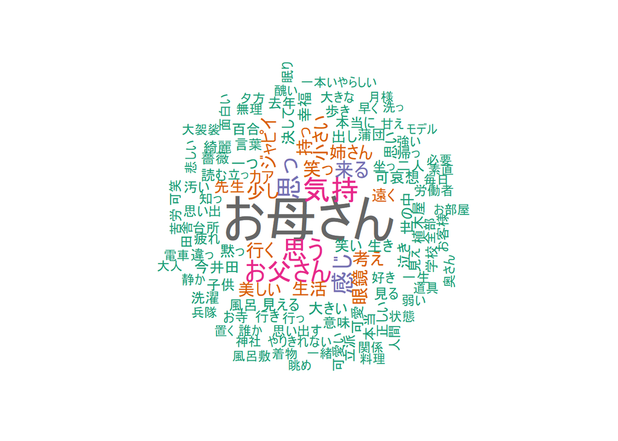

```r
library(quanteda.textplots)

set.seed(123)
textplot_wordcloud(dfm_dat_s,
                   random_order = FALSE,
                   rotation = .25,
                   min_count = 5,
                   min_size = 1,
                   max_size = 5,
                   color = RColorBrewer::brewer.pal(8, "Dark2"))
```

### 7.2.2 高頻度語を除去

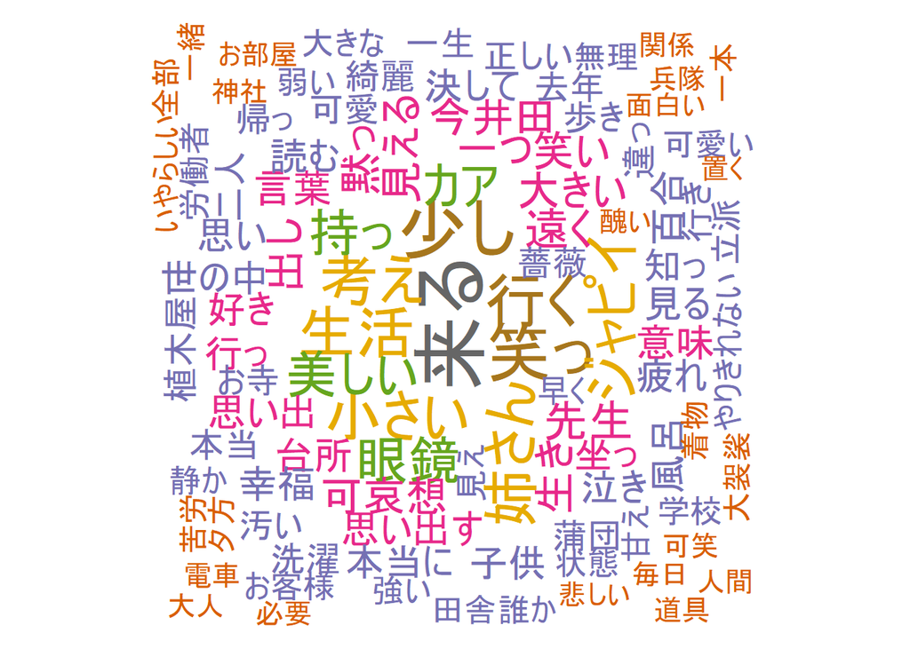

```r
set.seed(123)
textplot_wordcloud(dfm_dat_s2,
                   random_order = FALSE,
                   rotation = .25,
                   min_count = 5,
                   min_size = 1,
                   max_size = 5,
                   color = RColorBrewer::brewer.pal(8, "Dark2"))
```

## 7.3 共起ネットワーク

### 7.3.1 頻度の制限なし

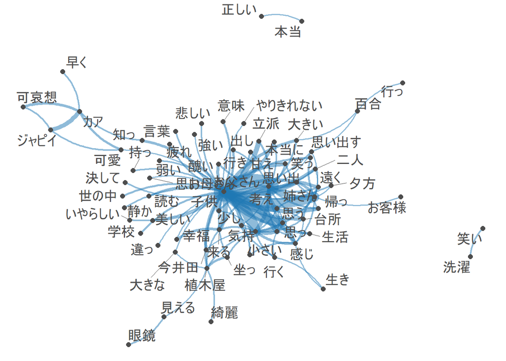

```r
feat <- names(topfeatures(dfm_dat_s, 100))

dfm_fcm <- fcm(dfm_dat_s)
dfm_dat_col <- fcm_select(dfm_fcm, feat)
textplot_network(dfm_dat_col, min_freq = 0.95, edge_size = 5)
```

```r
# topfeatures()はdfm形式のみに対応するため次の書き方はもう使わない
# feat <- names(topfeatures(dfm_fcm, 100))


# dfm_fcm <-
#   dfm_select(dfm_dat, feat) |>
#   fcm()
#
# size <-
#   sqrt(rowSums(dfm_fcm))
#
# textplot_network(dfm_fcm, min_freq = 0.85, edge_alpha = 0.9,
#                  vertex_size = size / max(size) * 3,
#                  vertex_labelfont = if (Sys.info()["sysname"] == "Darwin") "SimHei" else NULL)
```

### 7.3.2 高頻度語を除去

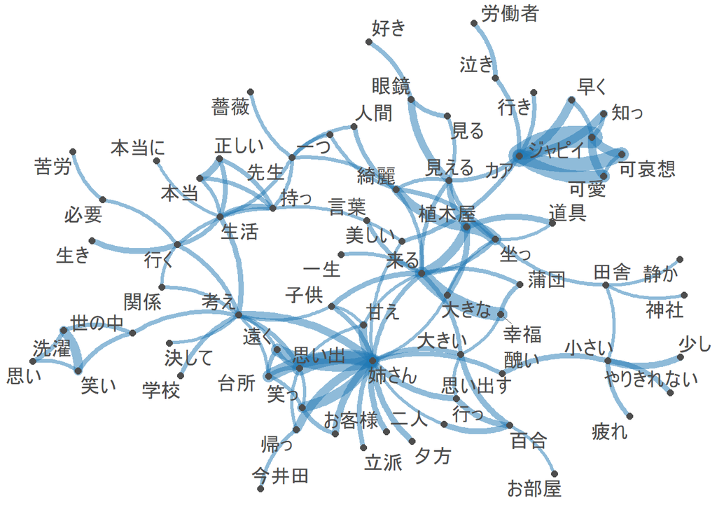

```r
feat2 <- names(topfeatures(dfm_dat_s2, 100))


dfm_fcm2 <- fcm(dfm_dat_s2)
dfm_dat_col2 <- fcm_select(dfm_fcm2, feat2)
textplot_network(dfm_dat_col2, min_freq = 0.95, edge_size = 5)
```

## 7.4 トピックモデル

```r
library(topicmodels)

set.seed(123)
lda <- LDA(convert(dfm_dat_s, to = "topicmodels"), k = 10) # kにトピック数

# 表示
get_terms(lda, 10) |> #上位10単語
  as_tibble() |>
  knitr::kable()
```

| Topic 1 | Topic 2 | Topic 3 | Topic 4 | Topic 5 | Topic 6 | Topic 7 | Topic 8 | Topic 9 | Topic 10 |
| --- | --- | --- | --- | --- | --- | --- | --- | --- | --- |
| お母さん | 思い | 生活 | ジャピイ | お母さん | 来る | 百合 | 眼鏡 | 気持 | 思う |
| 思っ | 洗濯 | お母さん | カア | お父さん | 植木屋 | 小さい | お父さん | 感じ | お母さん |
| 思う | 月様 | 気持 | 姉さん | 姉さん | 気持 | 労働者 | お母さん | 田舎 | 少し |
| 感じ | キウリ | 思っ | 感じ | 考え | 幸福 | お寺 | 思う | 今井田 | 歩き |
| 言葉 | 失敗 | 行く | 気持 | 思い出 | 道具 | 感じ | 気持 | 思っ | 美しい |
| 先生 | 笑い | 苦労 | 可哀想 | 気持 | お母さん | 行っ | 出し | 思う | 思っ |
| 気持 | 少し | 思う | 可愛 | 思う | 坐っ | 掃除 | 今井田 | 奥さん | カア |
| 少し | 読む | 持っ | 井戸端 | 二人 | 行く | 少し | 笑っ | 生き | 可哀想 |
| お父さん | 世の中 | 考え | 茱萸 | 醜い | 風呂敷 | 大きい | 見える | 坐っ | 持っ |
| 掛声 | 置く | 正しい | 作品 | 遠く | 本能 | 泣き | 好き | コトン | 考え |

```r
# LDA_fit_10 <- convert(dfm_fcm, to = "topicmodels") |>
#     LDA(k = 10)
```

## 7.5 （不使用）文単位に分割

# 8 参考（その他）

- [青空文庫からファイルを（半）自動ダウンロードでテキストマイニング（したい？）](http://rstudio-pubs-static.s3.amazonaws.com/3345_a88bc1244a08425d95772d0418f71048.html)

# 9 他のテキスト取得方法

## 9.1 web上から

- 太宰治[『女生徒』](https://www.aozora.gr.jp/cards/000035/files/275_13903.html)XHTML版 青空文庫

### 9.1.1 webページをRに読み込み

```r
library(rvest)

txt <- read_html("https://www.aozora.gr.jp/cards/000035/files/275_13903.html")
```

### 9.1.2 文字情報を取得

- `read_html()`で読み込んだオブジェクトから文字情報を取得
- テキストデータがひとかたまりで取得され，そのまま表示させると膨大な出力になるので，`str_sub()`で一部を確認

```r
txt_html <-
  txt |>
  html_text()

txt_html|>
  str_sub(1,500) # 1文字目から500文字目まで表示
```

```
## [1] "太宰治 女生徒\r\n\r\n女生徒\r\n太宰治\r\n\r\n\r\n　あさ、眼をさますときの気持は、面白い。かくれんぼのとき、押入れの真っ暗い中に、じっと、しゃがんで隠れていて、突然、でこちゃんに、がらっと襖（ふすま）をあけられ、日の光がどっと来て、でこちゃんに、「見つけた！」と大声で言われて、まぶしさ、それから、へんな間の悪さ、それから、胸がどきどきして、着物のまえを合せたりして、ちょっと、てれくさく、押入れから出て来て、急にむかむか腹立たしく、あの感じ、いや、ちがう、あの感じでもない、なんだか、もっとやりきれない。箱をあけると、その中に、また小さい箱があって、その小さ…
```

### 9.1.3 加工

#### 9.1.3.1 改行単位で区切る

- `str_split()`を使って，指定した区切り（ここでは改行）ごとに分割する。改行部分は`\r\n`
- 分割した結果はリストになっているので，リストの１要素目（“[[1]]”）を取り出す

```r
txt_split <-
  txt_html |>
  str_split("\r\n")

# 分割結果がリストになっているので抽出
txt_split <-
  txt_split[[1]]

# 最初の8個の分割確認
txt_split[1:8]
```

```
## [1] "太宰治 女生徒"
## [2] ""
## [3] "女生徒"
## [4] "太宰治"
## [5] ""
## [6] ""
## [7] "　あさ、眼をさますときの気持は、面白い。かくれんぼのとき、押入れの真っ暗い中に、じっと、しゃがんで隠れていて、突然、でこちゃんに、がらっと襖（ふすま）をあけられ、日の光がどっと来て、でこちゃんに、「見つけた！」と大声で言われて、まぶしさ、それから、へんな間の悪さ、それから、胸がどきどきして、着物のまえを合せたりして、ちょっと、てれくさく、押入れから出て来て、急にむかむか腹立たしく、あの感じ、いや、ちがう、あの感じでもない、なんだか、もっとやりきれない。箱をあけると、その中に、また小さい箱があって、その小さい箱をあけると、またその中に、もっと小さい箱があって、そいつをあけると、ま…
## [8] "　朝は、意地悪（いじわる）。"
```

```r
# 元データ削除
rm(txt)
```

#### 9.1.3.2 本文以外の情報を削除

- 本文以外の情報が分割結果のどこにあるか手動で確認

```r
txt_split |>
  as_tibble() |>
  slice_head(n = 10)
```

```
## # A tibble: 10 × 1
##    value
##    <chr>
##  1 "太宰治 女生徒"
##  2 ""
##  3 "女生徒"
##  4 "太宰治"
##  5 ""
##  6 ""
##  7 "　あさ、眼をさますときの気持は、面白い。かくれんぼのとき、押入れの真っ暗い…
##  8 "　朝は、意地悪（いじわる）。"
##  9 "「お父さん」と小さい声で呼んでみる。へんに気恥ずかしく、うれしく、起きて、…
## 10 "　朝は、いつでも自信がない。寝巻のままで鏡台のまえに坐る。眼鏡をかけないで…
```

```r
txt_split |>
  as_tibble() |>
  mutate(id = row_number()) |> # 行番号を示すためにid作成
  slice_tail(n = 20)
```

```
## # A tibble: 20 × 2
##    value                                                                      id
##    <chr>                                                                   <int>
##  1 "　眠りに落ちるときの気持って、へんなものだ。鮒（ふな）か、うなぎか、…    100
##  2 "　おやすみなさい。私は、王子さまのいないシンデレラ姫。あたし、東京の…    101
##  3 ""                                                                        102
##  4 ""                                                                        103
##  5 "底本：「女生徒」角川文庫、角川書店"                                      104
##  6 "　　　1954（昭和29）年10月20日初版発行"                                  105
##  7 "　　　1968（昭和43）年2月5日44版発行"                                    106
##  8 "入力：細渕真弓"                                                          107
##  9 "校正：細渕紀子"                                                          108
## 10 "1999年2月16日公開"                                                       109
## 11 "2011年5月22日修正"                                                       110
## 12 "青空文庫作成ファイル："                                                  111
## 13 "このファイルは、インターネットの図書館、青空文庫（http://www.aozora.g…   112
## 14 ""                                                                        113
## 15 ""                                                                        114
## 16 "●表記についてこのファイルは W3C 勧告 XHTML1.1 にそった形式で作成され…    115
## 17 "\t「くの字点」をのぞくJIS X 0213にある文字は、画像化して埋め込みまし…    116
## 18 ""                                                                        117
## 19 ""                                                                        118
## 20 "●図書カード"                                                             119
```

- 本文部分だけに限定

```r
txt_split <-
  txt_split[7:101]
```

- 確認

```r
txt_split |>
  as_tibble() |>
  slice_head(n = 3)
```

```
## # A tibble: 3 × 1
##   value
##   <chr>
## 1 　あさ、眼をさますときの気持は、面白い。かくれんぼのとき、押入れの真っ暗い中…
## 2 　朝は、意地悪（いじわる）。
## 3 「お父さん」と小さい声で呼んでみる。へんに気恥ずかしく、うれしく、起きて、さ…
```

```r
txt_split |>
  as_tibble() |>
  slice_tail(n = 3)
```

```
## # A tibble: 3 × 1
##   value
##   <chr>
## 1 　私は悲しい癖で、顔を両手でぴったり覆っていなければ、眠れない。顔を覆って、…
## 2 　眠りに落ちるときの気持って、へんなものだ。鮒（ふな）か、うなぎか、ぐいぐい…
## 3 　おやすみなさい。私は、王子さまのいないシンデレラ姫。あたし、東京の、どこに…
```

#### 9.1.3.3 ルビを取り除く

- ただし，（ ）の部分が全て削除になるので，読みがな以外の（ ）を残す工夫が必要

#### 9.1.3.4 確認

```r
# 除去前
txt_split[1]
```

```
## [1] "　あさ、眼をさますときの気持は、面白い。かくれんぼのとき、押入れの真っ暗い中に、じっと、しゃがんで隠れていて、突然、でこちゃんに、がらっと襖（ふすま）をあけられ、日の光がどっと来て、でこちゃんに、「見つけた！」と大声で言われて、まぶしさ、それから、へんな間の悪さ、それから、胸がどきどきして、着物のまえを合せたりして、ちょっと、てれくさく、押入れから出て来て、急にむかむか腹立たしく、あの感じ、いや、ちがう、あの感じでもない、なんだか、もっとやりきれない。箱をあけると、その中に、また小さい箱があって、その小さい箱をあけると、またその中に、もっと小さい箱があって、そいつをあけると、ま…
```

#### 9.1.3.5 すべての（）を確認

```r
yomigana <-
  txt_split |>
  str_extract_all("（[^）]+）") |>
  flatten_chr()

yomigana |>
  head()
```

```
## [1] "（ふすま）"   "（でんぷん）" "（うわずみ）" "（みにく）"   "（みもだ）"
## [6] "（いじわる）"
```

```r
# df_yomigana <-
#   yomigana |>
#   as_tibble()
#
# writexl::write_xlsx(df_yomigana, "out/df_yomigana.xlsx")
```

#### 9.1.3.6 漢字があるかどうか確認

```r
yomigana |>
  str_subset("[一-龠]")
```

```
## [1] "（可哀想（かわいそう）"
## [2] "（こんな言葉もどこかの本で読んだことがある）"
## [3] "（口だけでは、やれ古いのなんのって言うけれども、決して人生の先輩、老人、既婚の人たちを軽蔑なんかしていない。それどころか、いつでも二目（にもく）"
```

##### 9.1.3.6.1 個別に置換

```r
txt_split <-
  txt_split |>
  str_replace_all(c("（可哀想（かわいそう）" = "（可哀想",
                    "（口だけでは、やれ古いのなんのって言うけれども、決して人生の先輩、老人、既婚の人たちを軽蔑なんかしていない。それどころか、いつでも二目（にもく）" =
                      "（口だけでは、やれ古いのなんのって言うけれども、決して人生の先輩、老人、既婚の人たちを軽蔑なんかしていない。それどころか、いつでも二目"))
```

- 確認

```r
yomigana <-
  txt_split |>
  str_extract_all("（[^）]+）") |>
  flatten_chr()

yomigana |>
  str_subset("[一-龠]")
```

```
## [1] "（可哀想な犬だから、カアと呼ぶんだ）"
## [2] "（こんな言葉もどこかの本で読んだことがある）"
## [3] "（口だけでは、やれ古いのなんのって言うけれども、決して人生の先輩、老人、既婚の人たちを軽蔑なんかしていない。それどころか、いつでも二目も三目（さんもく）"
```

- 再度置換

```r
txt_split <-
  txt_split |>
  str_replace_all(c(
"（口だけでは、やれ古いのなんのって言うけれども、決して人生の先輩、老人、既婚の人たちを軽蔑なんかしていない。それどころか、いつでも二目も三目（さんもく）" =
"（口だけでは、やれ古いのなんのって言うけれども、決して人生の先輩、老人、既婚の人たちを軽蔑なんかしていない。それどころか、いつでも二目も三目"))

yomigana <-
  txt_split |>
  str_extract_all("（[^）]+）") |>
  flatten_chr()

yomigana |>
  str_subset("[一-龠]")
```

```
## [1] "（可哀想な犬だから、カアと呼ぶんだ）"
## [2] "（こんな言葉もどこかの本で読んだことがある）"
## [3] "（口だけでは、やれ古いのなんのって言うけれども、決して人生の先輩、老人、既婚の人たちを軽蔑なんかしていない。それどころか、いつでも二目も三目も置いているはずだ）"
```

#### 9.1.3.7 削除するよみがなの一覧を作成

- dplyr::setdiffで削除する要素を指定

```r
kanji <-
  yomigana |>
  str_subset("[一-龠]")

yomigana <-
  yomigana |>
  setdiff(kanji)




# 動かない
# kanji <-
#   yomigana |>
#   str_subset("[一-龠]")
#
# yomigana <-
#   yomigana |>
#   str_remove_all(all_of(kanji), "")
```

#### 9.1.3.8 (未完成)漢字を含むもの以外を確認

```r
yomigana |>
  str_subset("[^一-龠]")
```

```
##   [1] "（ふすま）"           "（でんぷん）"         "（うわずみ）"
##   [4] "（みにく）"           "（みもだ）"           "（いじわる）"
##   [7] "（ふとん）"           "（かっこう）"         "（ひんしゅく）"
##  [10] "（いや）"             "（けんか）"           "（さえぎ）"
##  [13] "（おか）"             "（うれ）"             "（いちご）"
##  [16] "（ふ）"               "（なつ）"             "（にお）"
##  [19] "（な）"               "（し）"               "（つち）"
##  [22] "（いき）"             "（ほうき）"           "（ばら）"
##  [25] "（ししゅう）"         "（おおわらわ）"       "（あたた）"
##  [28] "（と）"               "（みちばた）"         "（むし）"
##  [31] "（おおげさ）"         "（ひたい）"           "（うな）"
##  [34] "（しぼ）"             "（すそ）"             "（えり）"
##  [37] "（つば）"             "（う）"               "（たた）"
##  [40] "（え）"               "（い）"               "（くや）"
##  [43] "（とくとく）"         "（いしゅく）"         "（つか）"
```

[output cut: 30 more lines]

#### 9.1.3.9 句読点があるかどうか確認

```r
yomigana |>
  str_subset("[、。]")
```

```
## character(0)
```

#### 9.1.3.10 (未完成)ひらがなのみを確認

```r
yomigana |>
  str_subset("（[ぁ-ん]+）")
```

```
##   [1] "（ふすま）"           "（でんぷん）"         "（うわずみ）"
##   [4] "（みにく）"           "（みもだ）"           "（いじわる）"
##   [7] "（ふとん）"           "（かっこう）"         "（ひんしゅく）"
##  [10] "（いや）"             "（けんか）"           "（さえぎ）"
##  [13] "（おか）"             "（うれ）"             "（いちご）"
##  [16] "（ふ）"               "（なつ）"             "（にお）"
##  [19] "（な）"               "（し）"               "（つち）"
##  [22] "（いき）"             "（ほうき）"           "（ばら）"
##  [25] "（ししゅう）"         "（おおわらわ）"       "（あたた）"
##  [28] "（と）"               "（みちばた）"         "（むし）"
##  [31] "（おおげさ）"         "（ひたい）"           "（うな）"
##  [34] "（しぼ）"             "（すそ）"             "（えり）"
##  [37] "（つば）"             "（う）"               "（たた）"
##  [40] "（え）"               "（い）"               "（くや）"
##  [43] "（とくとく）"         "（いしゅく）"         "（つか）"
```

[output cut: 30 more lines]

#### 9.1.3.11 指定したよみがなを削除

```r
txt_split <-
  txt_split |>
  str_remove_all(str_c(yomigana, collapse = "|"))



# 除去後
txt_split[1]
```

```
## [1] "　あさ、眼をさますときの気持は、面白い。かくれんぼのとき、押入れの真っ暗い中に、じっと、しゃがんで隠れていて、突然、でこちゃんに、がらっと襖をあけられ、日の光がどっと来て、でこちゃんに、「見つけた！」と大声で言われて、まぶしさ、それから、へんな間の悪さ、それから、胸がどきどきして、着物のまえを合せたりして、ちょっと、てれくさく、押入れから出て来て、急にむかむか腹立たしく、あの感じ、いや、ちがう、あの感じでもない、なんだか、もっとやりきれない。箱をあけると、その中に、また小さい箱があって、その小さい箱をあけると、またその中に、もっと小さい箱があって、そいつをあけると、また、また、…
```